# Travel delayed is travel denied: An empirical study of flight delays and models that seek to predict their occurrence

Hari Subhash Mario

Date created: 2019-05-13

## Abstract

I then use a logistic regression model, and find that all five independent variables display a correlative relationship with departure delay at a 0.1 percent significance level. The data also suggest that scheduled departure time may be used to estimate the probability of departure delay as follows:<sup>2</sup>

> Probability of departure delay = 1 / (1 + e^-(0.28 - 0.002 * difference between 7:35 pm and scheduled departure time in minutes))

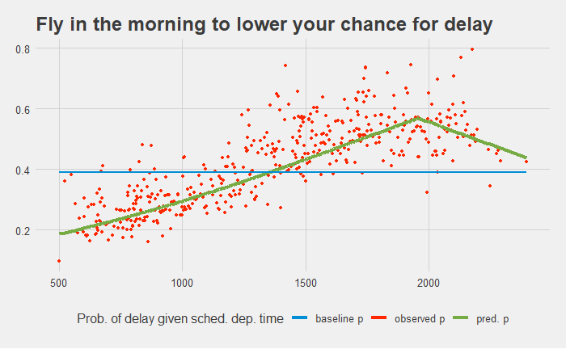

*<sup>1</sup> Bureau of Transportation Statistics, "Reporting Carrier On-Time Performance", via Rstudio*  
*<sup>2</sup> e refers to Euler's number, a mathematical constant roughly equal to 2.72*

## Background

### PROBLEM:

Flight delays are unpredictable. Mis-timing your ride to the airport could be costly; Arrive late and you may miss your flight altogether, but arrive early and you'll spend even more uncomfortable, unproductive time at the gate. In an ideal world, all flights would simply leave on time. In a second-best world, each airline would contact travelers directly with flight delay information that was accurate and timely enough to be actionable. Alas, neither of those are the case.

### GOAL:

My ultimate goal is to be able to best predict whether a flight will be delayed using weather, plane, and flight data.

### HYPOTHESIS:

My null hypothesis is that *no* available weather, plane, or flight data shares a relationship with flight delay. I'll seek to disprove this.

## Setting up

To set up, I'll do the following:

1. Set a baseline probability
2. Link flight data with data to the planes flown and the weather contemporaneous to each flight
3. Find a baseline probability for departure delay
4. Clean and adapt the data both so that it makes sense logically and is testable; This will include:
   1. Setting negative departure delay values equal to zero<sup>3</sup>
   2. Replacing categorical data -- such as the name of an airline -- with an "object effect" that estimates the added chance for delay associated with any object
5. Start an appendix of metadata, including:
   1. A data dictionary
   2. A data lineage diagram

### BASELINE

I'll set a baseline probability by finding how many flights were delayed in 2013 and dividing by the total number of flights, while accounting for flights that didn't have delay information available.

The baseline probability of delay is 39.094 percent

### JOIN DATA TABLES

Link tables of flight, plane, and weather data together to create a thick data set

### REMOVE IRRELEVANT COLUMNS

Some flight, plane, and weather data are irrelevant or redundant and may be removed

### MUTATE SOME COLUMNS

First, convert scheduled departure time to a time object

Now to look at the delay data based on scheduled departure time

This graph appears to show that the probability of departure delay increases as the day moves along, peaks around 7:35 p.m., then drops again until midnight.

To verify the time numerically, find the correlation with observed probability for each time, then find the max among the outputs.

| i | cor_i |
| --- | --- |
| 19:35 | -0.2401508 |

The max correlation is at 7:35 p.m.

The numbers confirm what the graph suggests. Based on the assumption that the delays are approximately symmetric about 7:35 p.m., mutate scheduled departure time by finding the time difference between each scheduled flight time and 7:35 p.m.

Mutate the other categorical variables. Categorical variables may be used as inputs in a logistic regression. However, I'll mutate them here into an effect that reflects the difference associated with any given carrier, origin airport, and so forth:

<sup>3</sup> A negative departure delay value would decrease a category mean as though it is "more on time". To better intuit this, suppose an airline has one flight that leaves 30 minutes early and another that leaves 30 minutes late every day. On paper, the mean of 0 minutes delayed would appear as though a traveler need not worry about delays when flying on this airline, but this is not the case; Rather, there's a 50 percent chance they'll depart late. Because of that, I chose to zero out negative departure delay values.

## Univariate analysis

Here are the steps for this

1. Explore metadata to ensure understanding of what each variable represents
2. Descriptive statics of the dependent variable, departure delay, including number of observations, mean, standard deviation, median, min, max, and interquartile measures
3. A histogram will offer a visual representation

Doing this will expose:

- Fields that would be unlikely related to departure delay,
- Fields that will require transformation, and
- Fields with too few observations or with too many missing observations to be representative

### ADDITIONAL METADATA

The package's documentation offers extensive metadata information.<sup>4</sup>

See appendix for data dictionary and data lineage

### DESCRIPTIVE STATS OF THE DEPENDENT VARIABLE:

Let's look at 6 percentiles to verify that this is not normal by checking the probabilities associated with one-tailed z-scores of 0.5 to 3.0, by 0.5. If this were a normal distribution, the difference between the delay values associated with these z-scores would be approximtely equal.

```
69.15% 84.13% 93.32% 97.72% 99.38% 99.87%
     5     27     71    137    222    323
```

In a normal distribution, the distance between each of these would be equal. **It would make more sense to predict the probability of any delay given other factors rather than trying to predict the length of a delay**

To start on building a logistic regression, find a baseline value for the probability that a flight will be delayed, using only the dep_delay column and produce a fairly boring graph

That baseline is 39 percent. This needs to be graphed

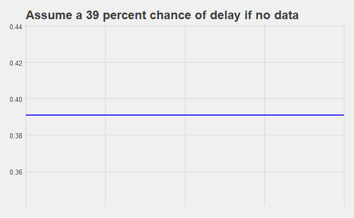

*<sup>4</sup> See [nycflights documentation](https://cran.r-project.org/web/packages/nycflights13/nycflights13.pdf)*

## Multivariate analysis

There are steps here too

1. Descriptive statistics for the independent variables
2. Explore relationships between variables
3. Find correlation with our dependent variable
4. Model the best relationships

### Descriptive statistics for the independent variables

Based on the data dictionary, the following fields are either unlikely to be related to departure delay or duplicative of another, superior field in the data set

- Destination
- Tail number
- Arrival time
- Day of the month
- Flight number
- Scheduled arrival time
- Year
- Air time
- Arrival delay
- Departure time
- Distance

Only one field among those remaining, **wind gust**, is concerning due to the number of n/a entries -- 256,391 of 336,776 total. My fear is that these incomplete entries are biased -- that is, we may be telling a story that is based on a sample of the data that does not represent the poopulation.

To test, I'll produce summary statistics for wind gusts that are present and missing:

| na_gust | p_del | n_del |
| --- | --- | --- |
| 0 | 0.38 | 250787 |
| 1 | 0.42 | 77734 |

The data looks similar enough. Now to see if the graphs look similar

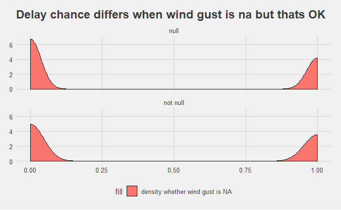

These look similar enough to work with. To further verify with numbers, I would do a z-test to see if I'm able to disprove that the means are unequal and an f-test to do the same with the standard deviations. But not today. Today, I will do neither.

### Explore relationships

In testing departure delay and our other variables, I'll be looking for relationships that show a strong, correlative relationship.

To do this, I'll use R's general linear model (glm) tool. This will expose the strength of each relationship by providing a p-value, which estimates the probability that we'd get at least as extreme a result if NYC flights 2013 were repeated forever. Because we want there to be *little* chance that sampling the actual population gives us results that are extreme relative to our model, we want p-values that are as low as possible.

**I will test the dataset I've created with a significance level of 0.1 percent.**

```
Call:
glm(formula = is_delay ~ distance + manuf_year + engines + seats +
    speed + month.y + temp + dewp + humid + wind_dir + wind_speed +
    wind_gust + precip + pressure + visib + diff_1935h + op_carr +
    op_ogn + op_type + op_mnf + op_mdl + op_spd + op_eng, family = binomial,
    data = flt_test_03)

Deviance Residuals:
    Min       1Q   Median       3Q      Max
-1.9010  -0.7656  -0.5738   0.7643   2.2693

Coefficients:
              Estimate Std. Error z value Pr(>|z|)
(Intercept) -1.838e+02  1.217e+02  -1.510   0.1310
distance     3.718e-04  5.108e-04   0.728   0.4668
manuf_year   6.750e-02  4.572e-02   1.476   0.1398
engines      1.947e-02  9.723e-01   0.020   0.9840
seats        1.734e-02  2.139e-02   0.811   0.4176
speed       -4.374e-03  8.405e-03  -0.520   0.6028
month.y     -7.066e-02  6.320e-02  -1.118   0.2635
temp         9.262e-02  9.409e-02   0.984   0.3249
dewp        -8.383e-02  1.041e-01  -0.805   0.4206
humid        7.336e-02  5.976e-02   1.228   0.2196
wind_dir     9.341e-04  2.224e-03   0.420   0.6744
wind_speed  -1.103e-01  7.839e-02  -1.407   0.1595
wind_gust    1.177e-01  6.623e-02   1.777   0.0756 .
precip       3.727e+00  3.810e+01   0.098   0.9221
pressure     1.532e-02  2.755e-02   0.556   0.5781
visib       -3.988e-02  2.502e-01  -0.159   0.8734
diff_1935h  -1.551e-03  8.472e-04  -1.831   0.0671 .
op_carr     -3.816e+02  4.360e+02  -0.875   0.3815
op_ogn      -6.436e-01  4.336e+00  -0.148   0.8820
op_type     -2.137e+01  1.279e+01  -1.671   0.0948 .
op_mnf      -1.229e+00  7.998e+00  -0.154   0.8779
op_mdl       4.904e+00  3.858e+00   1.271   0.2036
op_spd      -2.050e+00  4.810e+00  -0.426   0.6700
op_eng       4.528e+00  6.840e+00   0.662   0.5079
---
Signif. codes:  0 *** 0.001 ** 0.01 * 0.05 . 0.1   1

(Dispersion parameter for binomial family taken to be 1)

    Null deviance: 270.07  on 229  degrees of freedom
Residual deviance: 236.64  on 206  degrees of freedom
  (328291 observations deleted due to missingness)
AIC: 284.64

Number of Fisher Scoring iterations: 4
```

Iterate through the GLM test, limiting to fewer variables

```
Call:
glm(formula = is_delay ~ diff_1935h + humid + pressure + visib +
    op_carr + op_ogn + op_mnf + op_mdl + op_eng, family = binomial,
    data = flt_test_03)

Deviance Residuals:
    Min       1Q   Median       3Q      Max
-1.9195  -0.9547  -0.6814   1.1609   2.3134

Coefficients:
              Estimate Std. Error  z value Pr(>|z|)
(Intercept)  2.126e+01  5.682e-01   37.406  < 2e-16 ***
diff_1935h  -2.083e-03  1.654e-05 -125.944  < 2e-16 ***
humid        8.127e-03  2.588e-04   31.400  < 2e-16 ***
pressure    -2.080e-02  5.566e-04  -37.376  < 2e-16 ***
visib       -3.283e-02  3.083e-03  -10.648  < 2e-16 ***
op_carr      1.992e+00  8.898e-02   22.387  < 2e-16 ***
op_ogn       8.256e-01  9.769e-02    8.451  < 2e-16 ***
op_mnf      -4.129e-01  1.213e-01   -3.404 0.000663 ***
op_mdl       3.037e+00  8.582e-02   35.385  < 2e-16 ***
op_eng      -3.299e-01  1.767e-01   -1.867 0.061943 .
---
Signif. codes:  0 *** 0.001 ** 0.01 * 0.05 . 0.1   1

(Dispersion parameter for binomial family taken to be 1)

    Null deviance: 387265  on 292201  degrees of freedom
Residual deviance: 357872  on 292192  degrees of freedom
  (36319 observations deleted due to missingness)
AIC: 357892

Number of Fisher Scoring iterations: 4
```

### Find correlation with our dependent variable

The analysis could stop with nine variables. However, we should all be concerned with comingled variables. If, for example, we had found instead that both the length of an airplane and the weight of an airplane were associated with departure delays, we might inadvertantly telling the same story twice. That is, because length and weight are, presumably, associated with each other, including the second variable provides no additional information and may instead be crowding out another useful variable.

| diff_1935h | humid | pressure | visib | op_carr | op_ogn | op_mnf | op_mdl | op_eng | field |
| --- | --- | --- | --- | --- | --- | --- | --- | --- | --- |
| 1.00 | 0.20 | 0.08 | -0.08 | -0.01 | 0.00 | -0.01 | -0.03 | 0.00 | diff_1935h |
| 0.20 | 1.00 | -0.15 | -0.54 | 0.01 | 0.05 | 0.03 | 0.00 | 0.03 | humid |
| 0.08 | -0.15 | 1.00 | 0.10 | 0.00 | 0.01 | 0.00 | 0.00 | 0.01 | pressure |
| -0.08 | -0.54 | 0.10 | 1.00 | 0.00 | -0.01 | -0.01 | 0.00 | -0.01 | visib |
| -0.01 | 0.01 | 0.00 | 0.00 | 1.00 | 0.45 | 0.52 | 0.79 | 0.37 | op_carr |
| 0.00 | 0.05 | 0.01 | -0.01 | 0.45 | 1.00 | 0.36 | 0.48 | 0.26 | op_ogn |
| -0.01 | 0.03 | 0.00 | -0.01 | 0.52 | 0.36 | 1.00 | 0.58 | 0.59 | op_mnf |
| -0.03 | 0.00 | 0.00 | 0.00 | 0.79 | 0.48 | 0.58 | 1.00 | 0.35 | op_mdl |
| 0.00 | 0.03 | 0.01 | -0.01 | 0.37 | 0.26 | 0.59 | 0.35 | 1.00 | op_eng |

In seeing this correlation table, it's clear that some of our predictor variables may be comingling with each other. Get rid of variables in the relationships with the highest absolute values. Also, those relationships should make logical sense.

Humidity is highly correlated with visibility. This makes sense since more water vapor in the air could make it more difficult to see. -humid

Carrier is highly correlated with four variables which are also correlated with each other -- airport of origin, manufacturer, model, and engine. This makes sense because having more of its planes concentrated at one airport provides economies of scale and manufacturers -- who sell plane models with engines in them -- are likely to cut a deal with those who buy in bulk. -op_mnf, -op_mdl, -op_eng

This brings us to our final five variables: diff_1935h, pressure, visib, op_carr, and op_ogn

### Model the best relationships

To figure out which single variable is most closely associated with probability of flight delay, I'll build another logistic regression model

```
Call:
glm(formula = is_delay ~ diff_1935h + pressure + visib + op_carr +
    op_ogn, family = binomial, data = flt_final)

Deviance Residuals:
    Min       1Q   Median       3Q      Max
-1.9010  -0.9667  -0.6885   1.1706   2.3141

Coefficients:
              Estimate Std. Error z value Pr(>|z|)
(Intercept)  2.438e+01  5.571e-01   43.76   <2e-16 ***
diff_1935h  -1.998e-03  1.625e-05 -122.97   <2e-16 ***
pressure    -2.303e-02  5.497e-04  -41.91   <2e-16 ***
visib       -7.739e-02  2.717e-03  -28.48   <2e-16 ***
op_carr      4.185e+00  5.987e-02   69.91   <2e-16 ***
op_ogn       1.732e+00  9.390e-02   18.45   <2e-16 ***
---
Signif. codes:  0 *** 0.001 ** 0.01 * 0.05 . 0.1   1

(Dispersion parameter for binomial family taken to be 1)

    Null deviance: 387265  on 292201  degrees of freedom
Residual deviance: 360123  on 292196  degrees of freedom
  (36319 observations deleted due to missingness)
AIC: 360135

Number of Fisher Scoring iterations: 4

 (Intercept)   diff_1935h     pressure        visib      op_carr       op_ogn
24.377394643 -0.001998325 -0.023033774 -0.077389351  4.185103561  1.732298346
```

Among these, diff_1935h appears to be the best. To get a result with only one input, I repeat the same:

```
Call:
glm(formula = is_delay ~ diff_1935h, family = binomial, data = flt_final)

Deviance Residuals:
    Min       1Q   Median       3Q      Max
-1.2982  -1.0160  -0.7482   1.1903   1.8314

Coefficients:
              Estimate Std. Error z value Pr(>|z|)
(Intercept)  0.2796037  0.0063033   44.36   <2e-16 ***
diff_1935h  -0.0019995  0.0000148 -135.08   <2e-16 ***
---
Signif. codes:  0 *** 0.001 ** 0.01 * 0.05 . 0.1   1

(Dispersion parameter for binomial family taken to be 1)

    Null deviance: 439671  on 328520  degrees of freedom
Residual deviance: 420235  on 328519  degrees of freedom
AIC: 420239

Number of Fisher Scoring iterations: 4

 (Intercept)   diff_1935h
 0.279603750 -0.001999519
```

Here is the equation that estimates the probability of a flight being delayed using one input:

1/(1+e^-(0.279603750 - 0.001999519 x diff_1935h))

Now that I've got this equation, I'll plot the observed probability for each group of scheduled departure times on the same graph as my predicted probability. First, I'll find and plot the actual probabilities from 2013.

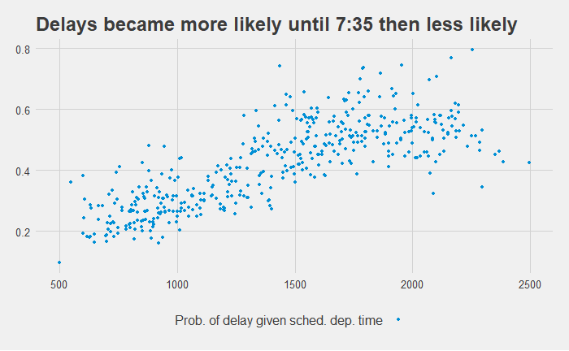

First, add baseline probability

Next, add prediction using bivariate model

I can also add a prediction using the multivariate model, but will not be able to graph it (in fewer than six dimensions)

Before plotting the predicted values, I'll create a function that returns mean squared error and use it on the three prediction models

```
[1] "op_base"
[1] "sse  4542  mse  0.01695"
[1] "pred_bivar"
[1] "sse  927.5  mse  0.003462"
[1] "pred_multivar"
[1] "sse  3069  mse  0.01146"
```

Looks like the bivariate model is the best. But let's plot all 3

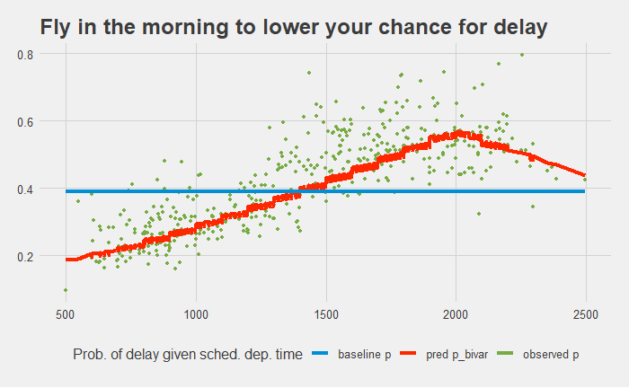

## Test formula using a succeeding year's data

There are updates to the flight data for as recently as 2017 at this Github repository: https://github.com/jayleetx/nycflights .

Let's see how the formula did at predicting. You may want to download this file and store it in the directory you have this notebook in: http://mariobonifacio.github.io/flights_17.csv

[output not shown]

## Ax.1 Metadata

**DATA LINEAGE**

The following may serve as a data lineage diagram

| Original_source | nycflights13 | raw_data_joined | adapted_data |
| --- | --- | --- | --- |
| transtats.bts.gov/ DL_SelectFields.asp? Table_ID=236 | airlines | n/a | n/a |
| RITA, Bureau of transportation statistics,transtats.bts.gov/ DL_SelectFields.asp? Table_ID=236 | flights | flt_raw | flt_test |
| FAA Aircraft registry,faa.gov/ licenses_certificates/ aircraft_certification/ aircraft_registry/ releasable_aircraft_download/ | planes | flt_raw | flt_test |
| ASOS download from Iowa Environmental Mesonet, mesonet.agron.iastate.edu/ request/ download.phtml | weather | flt_raw | flt_test |

**DATA DICTIONARY**

The following table links assets as saved in nycflights13 with associated terms and definitions.

| table | field | term | definition |
| --- | --- | --- | --- |
| flights | year | year,month,day | Date of departure or date of weather recording |
| flights | month | year,month,day | Date of departure or date of weather recording |
| flights | day | year,month,day | Date of departure or date of weather recording |
| flights | dep_time | dep_time,arr_time | Actual departure and arrival times (format HHMM or HMM), local tz. |
| flights | sched_dep_time | sched_dep_time,sched_arr_time | Scheduled departure and arrival times (format HHMM or HMM), local tz. |
| flights | dep_delay | dep_delay,arr_delay | Departure and arrival delays, in minutes. Negative times represent early departures/arrivals. |
| flights | arr_time | dep_time,arr_time | Actual departure and arrival times (format HHMM or HMM), local tz. |
| flights | sched_arr_time | sched_dep_time,sched_arr_time | Scheduled departure and arrival times (format HHMM or HMM), local tz. |
| flights | arr_delay | dep_delay,arr_delay | Departure and arrival delays, in minutes. Negative times represent early departures/arrivals. |
| flights | carrier | carrier | Two letter carrier abbreviation. See airlines() to get name |
| flights | flight | flight | Flight number |
| flights | tailnum | tailnum | Plane tail number |
| flights | origin | origin | Origin of flight or weather station |
| flights | dest | dest | Destination of flight. See airports() for additional metadata. |
| flights | air_time | air_time | Amount of time spent in the air, in minutes |
| flights | distance | distance | Distance between airports, in miles |
| flights | hour | hour | Hour part of time of scheduled departure or weather recording |
| flights | minute | minute | Minute part of time of scheduled departure |
| flights | time_hour | time_hour | Scheduled date and hour of the flight or of the weather recording as a POSIXct date |
| weather | origin | origin | Origin of flight or weather station |
| weather | year | year,month,day | Date of departure or date of weather recording |
| weather | month | year,month,day | Date of departure or date of weather recording |
| weather | day | year,month,day | Date of departure or date of weather recording |
| weather | hour | hour | Hour part of time of scheduled departure or weather recording |
| weather | temp | temp,dewp | Temperature and dewpoint in F |
| weather | dewp | temp,dewp | Temperature and dewpoint in F |
| weather | humid | humid | Relative humidity |
| weather | wind_dir | wind_dir,wind_speed,wind_gust | Wind direction (in degrees), speed and gust speed (in mph) |
| weather | wind_speed | wind_dir,wind_speed,wind_gust | Wind direction (in degrees), speed and gust speed (in mph) |
| weather | wind_gust | wind_dir,wind_speed,wind_gust | Wind direction (in degrees), speed and gust speed (in mph) |
| weather | precip | precip | Precipitation, in inches |
| weather | pressure | pressure | Sea level pressure in millibars |
| weather | visib | visib | Visibility in miles |
| weather | time_hour | time_hour | Scheduled date and hour of the flight or of the weather recording as a POSIXct date |
| planes | tailnum | tailnum | Plane tail number |
| planes | year | year(2) | Year manufactured,Renamed to manuf_year |
| planes | type | type | Type of plane |
| planes | manufacturer | manufacturer,model | Manufacturer and model |
| planes | model | manufacturer,model | Manufacturer and model |
| planes | engines | engines,seats | Number of engines and seats |
| planes | seats | engines,seats | Number of engines and seats |
| planes | speed | speed | Average cruising speed in mph |
| planes | engine | engine | Type of engine |

This table represents a table of static data linking airline codes to airline descriptions:

| carrier_code | carrier_description |
| --- | --- |
| 9E | Endeavor Air Inc. |
| AA | American Airlines Inc. |
| AS | Alaska Airlines Inc. |
| B6 | JetBlue Airways |
| DL | Delta Air Lines Inc. |
| EV | ExpressJet Airlines Inc. |
| F9 | Frontier Airlines Inc. |
| FL | AirTran Airways Corporation |
| HA | Hawaiian Airlines Inc. |
| MQ | Envoy Air |
| OO | SkyWest Airlines Inc. |
| UA | United Air Lines Inc. |
| US | US Airways Inc. |
| VX | Virgin America |
| WN | Southwest Airlines Co. |
| YV | Mesa Airlines Inc. |

## Ax.2 For further study

### On working with a binary delay rather than a time of delay

Here's the histogram for dep_delay again

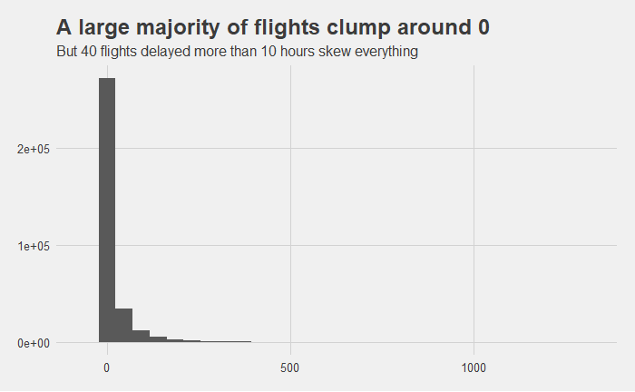

```r
flights %>%
  ggplot(mapping = aes(dep_delay)) +
  geom_histogram(na.rm = T) +
  theme_fivethirtyeight() +
  scale_color_fivethirtyeight() +
  labs(title = 'A large majority of flights clump around 0'
         ,subtitle = paste('But', sum(flights$dep_delay >= 600, na.rm = T), 'flights delayed more than 10 hours skew everything'))
```

Regardless of which category I grouped flights by, it was apparent that most flights in 2013 saw little to no delay. However, because there were a handful of outliers, it could skew the data when using mean, dramatically altering my results for a categorical variable. In turn, my predictions based on mean would be pretty far off most of the time, and only useful when averaging out a large number of flights that any given traveler might not make in a lifetime.

As an example, suppose a carrier was on time 99 times, but once, due to a fluke occurence of icy rain, was delayed by 15 hours.

### Picking a cutoff

One concern I had with this approach was ignoring much of the data. In particular, ignoring the magnitude of delay mattered because cutting off delayed vs. not delayed at 0 minutes was somewhat arbitrary.

There's a differnce between being delayed five minutes and being delayed an hour -- few would even notice the former while the latter would require a phone call or two to change plans.

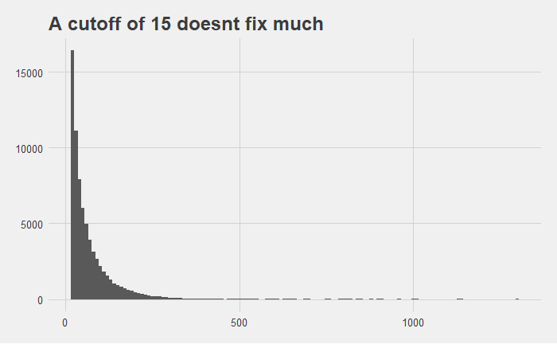

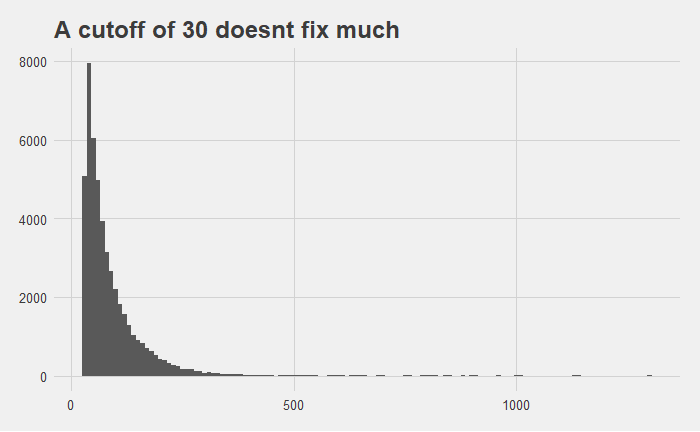

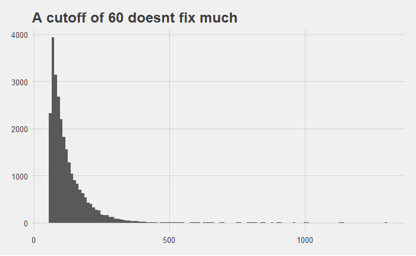

|  | i | skew_rightward | i_ratio_of_rightward | mdn_rightward | mean_rightward |
| --- | --- | --- | --- | --- | --- |
| 1 | 0 | 5.08 | 0.61 | 0 | 15 |
| 2 | 1 | 3.45 | 0.06 | 19 | 39 |
| 3 | 2 | 3.39 | 0.05 | 21 | 42 |
| 4 | 3 | 3.36 | 0.05 | 24 | 44 |
| 5 | 4 | 3.32 | 0.04 | 25 | 46 |
| 6 | 5 | 3.29 | 0.04 | 27 | 48 |
| 7 | 6 | 3.27 | 0.04 | 29 | 50 |
| 8 | 7 | 3.25 | 0.04 | 31 | 52 |
| 9 | 8 | 3.23 | 0.04 | 33 | 54 |
| 10 | 9 | 3.21 | 0.03 | 34 | 55 |

[output cut: 111 more lines]

All bad choices. I generally wouldn't want a skew outside the range of -2 to 2. This never comes close.

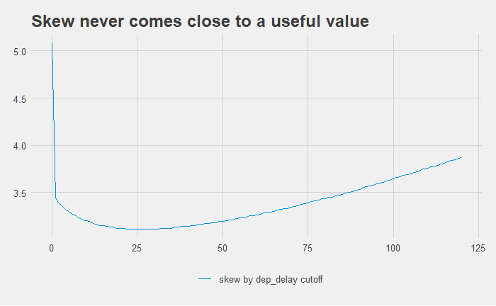

### Adding a second-level test for expected minutes delayed given that a flight is delayed

See the previous section. The heavy skew of the data means that number is likely to be off by a good amount.

### Variables not considered

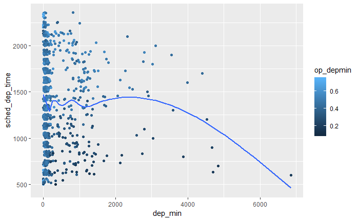